# Novogene bulk RNA-seq: srp versus dsRed control

Save this file in `scripts/` and click **Knit** in RStudio. Input is `../data/gene_count.xls`; tables, PDFs, model objects and the HTML report go to `../outs`. Positive log2 fold change means higher expression in srp (condition) relative to dsRed/dRed (control). `srp_8_9_26` and `srp_27_8_26` are condition samples; `dsRed_8_9_26` and `dRed_27_8_26` are controls.

This script uses your working R 4.3.1 environment with BiocManager already installed for the appropriate Bioconductor version.

Install dependencies once in that environment, outside knitting:

```r
# Optional missing dependencies only, using your existing R 4.3.1 environment.
install.packages(c("readxl", "ggrepel",
                   "rmarkdown",
                   "knitr"))
BiocManager::install(c("apeglm"), ask = FALSE, update = FALSE)
```

## Import and design

Raw gene counts are used; FPKM and group averages are unsuitable inputs. Processing date is modeled as a batch, **not a biological pairing**. The additive model assumes a common condition effect across dates; four samples cannot support a batch-by-condition interaction. Only one residual degree of freedom remains. Set `adjust_batch <- FALSE` only if processing date is known not to represent a relevant batch, not because it yields more significant genes.

```r
knitr::opts_chunk$set(echo = TRUE, fig.width = 8, fig.height = 5)
suppressPackageStartupMessages({
  library(DESeq2)
  library(tidyverse)
  library(ggrepel)
  library(pheatmap)
})
set.seed(42)
out <- "../outs"
dir.create(out, recursive = TRUE, showWarnings = FALSE)
alpha <- 0.05
lfc_cut <- 1                     # Descriptive |log2FC| cutoff; not a threshold test
adjust_batch <- TRUE
save_plot <- function(p, name, height = 5) {
  print(p)
  ggsave(file.path(out, paste0(name, ".pdf")), p, width = 8, height = height)
}
meta <- tibble(
  sample = c("srp_8_9_26", "dsRed_8_9_26", "srp_27_8_26", "dRed_27_8_26"),
  condition = factor(c("srp", "control", "srp", "control"),
                     levels = c("control", "srp")),
  batch = factor(c("2026-09-08", "2026-09-08", "2026-08-27", "2026-08-27"))
)

# Detect real Excel files by their signature; Novogene often supplies TSV as .xls.
path <- "../data/gene_count.xls"
signature <- readBin(path, "raw", n = 8)
excel <- (length(signature) >= 2 &&
          identical(signature[1:2], as.raw(c(0x50, 0x4b)))) ||
         identical(signature, as.raw(c(0xd0, 0xcf, 0x11, 0xe0, 0xa1, 0xb1, 0x1a, 0xe1)))
tab <- if (excel) {
  reader <- if (identical(signature[1:2], as.raw(c(0x50, 0x4b))))
    readxl::read_xlsx else readxl::read_xls
  reader(path, col_types = "text", .name_repair = "minimal")
} else {
  readr::read_tsv(path, col_types = cols(.default = col_character()),
                  na = c("", "NA"), quote = "", name_repair = "minimal")
}
stopifnot(!anyDuplicated(names(tab)),
          all(c("gene_id", "gene_name", "gene_biotype", meta$sample) %in% names(tab)))
ann <- tab %>% dplyr::select(-all_of(meta$sample))
stopifnot(!anyNA(ann$gene_id), !any(ann$gene_id == ""), !anyDuplicated(ann$gene_id))
cts <- tab %>% dplyr::select(all_of(meta$sample)) %>%
  mutate(across(everything(), as.numeric)) %>% as.matrix()
stopifnot(all(is.finite(cts)), all(cts >= 0), all(cts == floor(cts)),
          all(cts <= .Machine$integer.max), all(colSums(cts) > 0))
storage.mode(cts) <- "integer"  # Validation above prevents silent rounding.
rownames(cts) <- ann$gene_id
coldata <- as.data.frame(meta) %>% column_to_rownames("sample")
stopifnot(identical(colnames(cts), rownames(coldata)))
design_formula <- if (adjust_batch) ~ batch + condition else ~ condition
mm <- model.matrix(design_formula, coldata)
stopifnot(qr(mm)$rank == ncol(mm), nrow(mm) > ncol(mm))
knitr::kable(meta)
```

| sample | condition | batch |
| --- | --- | --- |
| srp_8_9_26 | srp | 2026-09-08 |
| dsRed_8_9_26 | control | 2026-09-08 |
| srp_27_8_26 | srp | 2026-08-27 |
| dRed_27_8_26 | control | 2026-08-27 |

```r
cat("Residual degrees of freedom:", nrow(mm) - ncol(mm), "\n")
```

```
## Residual degrees of freedom: 1
```

```r
write_csv(meta, file.path(out, "sample_metadata.csv"))
```

## Count-level QC

Assigned gene counts are not total sequenced reads. rRNA and dominance of a few genes can reveal composition problems; assess these against the intended library preparation. All biotypes are retained in the model.

```r
rrna <- grepl("rRNA", ann$gene_biotype, ignore.case = TRUE)
rrna[is.na(rrna)] <- FALSE
qc <- meta %>% mutate(
  assigned_counts = colSums(cts),
  detected_genes = colSums(cts > 0),
  rRNA_percent = 100 * colSums(cts[rrna, , drop = FALSE]) / colSums(cts),
  top10_percent = 100 * apply(cts, 2, function(x) sum(head(sort(x, decreasing = TRUE), 10))) /
                  colSums(cts)
)
knitr::kable(qc, digits = 2)
```

| sample | condition | batch | assigned_counts | detected_genes | rRNA_percent | top10_percent |
| --- | --- | --- | --- | --- | --- | --- |
| srp_8_9_26 | srp | 2026-09-08 | 20472999 | 13195 | 2.29 | 8.10 |
| dsRed_8_9_26 | control | 2026-09-08 | 20175842 | 12786 | 2.70 | 8.23 |
| srp_27_8_26 | srp | 2026-08-27 | 17388817 | 12939 | 3.40 | 9.15 |
| dRed_27_8_26 | control | 2026-08-27 | 17253696 | 12836 | 4.39 | 10.32 |

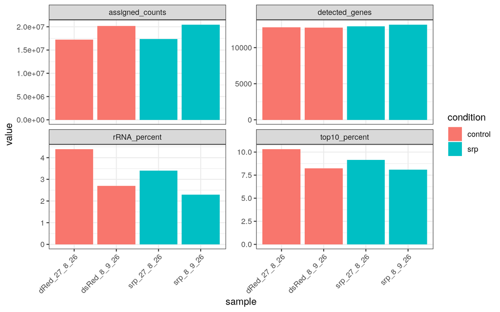

```r
write_csv(qc, file.path(out, "sample_QC.csv"))
save_plot(qc %>% pivot_longer(c(assigned_counts, detected_genes, rRNA_percent, top10_percent),
                             names_to = "metric", values_to = "value") %>%
  ggplot(aes(sample, value, fill = condition)) + geom_col() +
  facet_wrap(~ metric, scales = "free_y") + theme_bw() +
  theme(axis.text.x = element_text(angle = 45, hjust = 1)), "count_QC", 7)
```

## Fit and differential expression

Keep genes with at least 10 counts in at least two samples, including genes expressed only in one condition. DESeq2 additionally performs independent filtering. Tests use unshrunken coefficients; apeglm shrinkage is for displaying and ranking effect sizes. Missing adjusted P values remain missing.

```r
keep <- rowSums(cts >= 10) >= 2
stopifnot(sum(keep) >= 2)
cat("Retained", sum(keep), "of", nrow(cts), "genes.\n")
```

```
## Retained 10896 of 14526 genes.
```

```r
dds <- DESeqDataSetFromMatrix(cts[keep, , drop = FALSE], coldata, design_formula)
dds <- DESeq(dds)
res <- results(dds, contrast = c("condition", "srp", "control"), alpha = alpha)
shr <- lfcShrink(dds, coef = "condition_srp_vs_control", res = res, type = "apeglm")
res_tbl <- as.data.frame(res) %>% rownames_to_column("gene_id") %>%
  mutate(log2FC_shrunken = shr$log2FoldChange,
         label = gene_id) %>% left_join(ann, by = "gene_id") %>%
  mutate(label = if_else(is.na(gene_name) | gene_name %in% c("", "-"),
                         gene_id, paste0(gene_name, " [", gene_id, "]")),
         DEG = !is.na(padj) & padj < alpha,
         large_effect_DEG = DEG & abs(log2FC_shrunken) >= lfc_cut) %>%
  arrange(padj, desc(abs(log2FC_shrunken)))
write_csv(res_tbl, file.path(out, "DESeq2_all_tested_genes.csv"))
write_csv(dplyr::filter(res_tbl, DEG), file.path(out, "DESeq2_FDR05.csv"))
write_csv(dplyr::filter(res_tbl, large_effect_DEG), file.path(out, "DESeq2_FDR05_LFC1.csv"))
norm <- counts(dds, normalized = TRUE)
write_csv(as.data.frame(norm) %>% rownames_to_column("gene_id"),
          file.path(out, "normalized_counts.csv"))
qc$size_factor <- sizeFactors(dds)
write_csv(qc, file.path(out, "sample_QC.csv"))
summary(res)
```

```
##
## out of 10896 with nonzero total read count
## adjusted p-value < 0.05
## LFC > 0 (up)       : 565, 5.2%
## LFC < 0 (down)     : 857, 7.9%
## outliers [1]       : 0, 0%
## low counts [2]     : 845, 7.8%
## (mean count < 17)
## [1] see 'cooksCutoff' argument of ?results
## [2] see 'independentFiltering' argument of ?results
```

## Dispersion, PCA and sample distances

Dispersion describes count variability after accounting for the model. Inspect fit quality and high-dispersion genes. PCA and distances use rlog counts; `blind = FALSE` uses the fitted dispersion trend and does **not** remove batch effects. Look for condition clustering, date clustering and inconsistent replicates. PCA alone is not grounds to remove a sample.

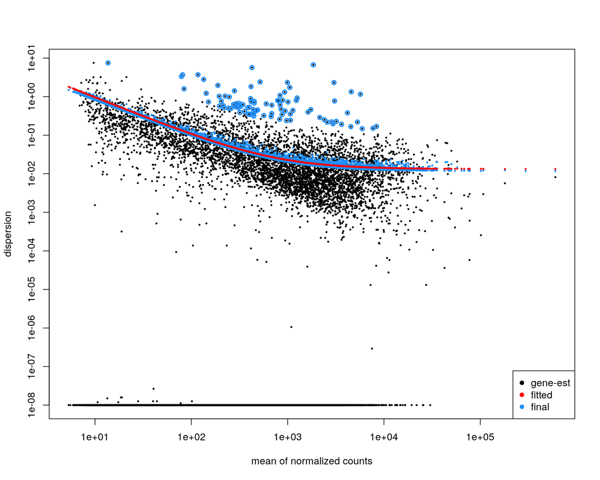

```r
plotDispEsts(dds)
```

```r
pdf(file.path(out, "dispersion.pdf"), width = 7, height = 5)
plotDispEsts(dds)
dev.off()
```

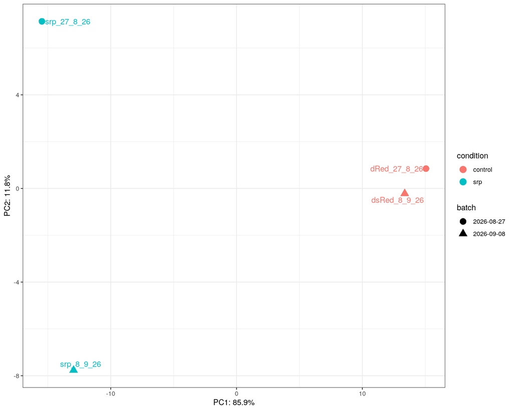

```r
rld <- rlog(dds, blind = FALSE)
pc <- plotPCA(rld, intgroup = c("condition", "batch"), returnData = TRUE,
              ntop = min(500, nrow(dds)))
pv <- round(100 * attr(pc, "percentVar"), 1)
save_plot(ggplot(pc, aes(PC1, PC2, color = condition, shape = batch, label = name)) +
  geom_point(size = 4) + geom_text_repel(seed = 42) + theme_bw() +
  labs(x = paste0("PC1: ", pv[1], "%"), y = paste0("PC2: ", pv[2], "%")), "PCA")
```

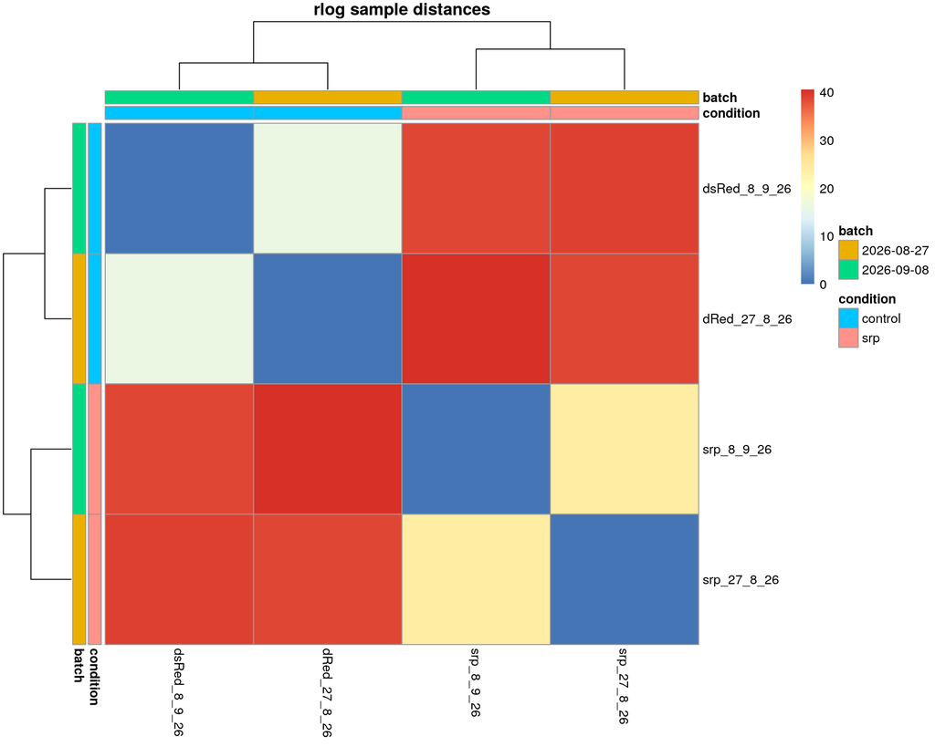

```r
annotation <- coldata[, c("condition", "batch"), drop = FALSE]
dist_mat <- as.matrix(dist(t(assay(rld))))
hc <- hclust(as.dist(dist_mat))
ph <- pheatmap(dist_mat, cluster_rows = hc, cluster_cols = hc,
              annotation_col = annotation, annotation_row = annotation,
              main = "rlog sample distances", silent = TRUE)
grid::grid.newpage(); grid::grid.draw(ph$gtable)
```

```r
pheatmap(dist_mat, cluster_rows = hc, cluster_cols = hc, annotation_col = annotation,
         annotation_row = annotation, filename = file.path(out, "sample_distances.pdf"))
```

## Most variable genes and good p_adj DEGs

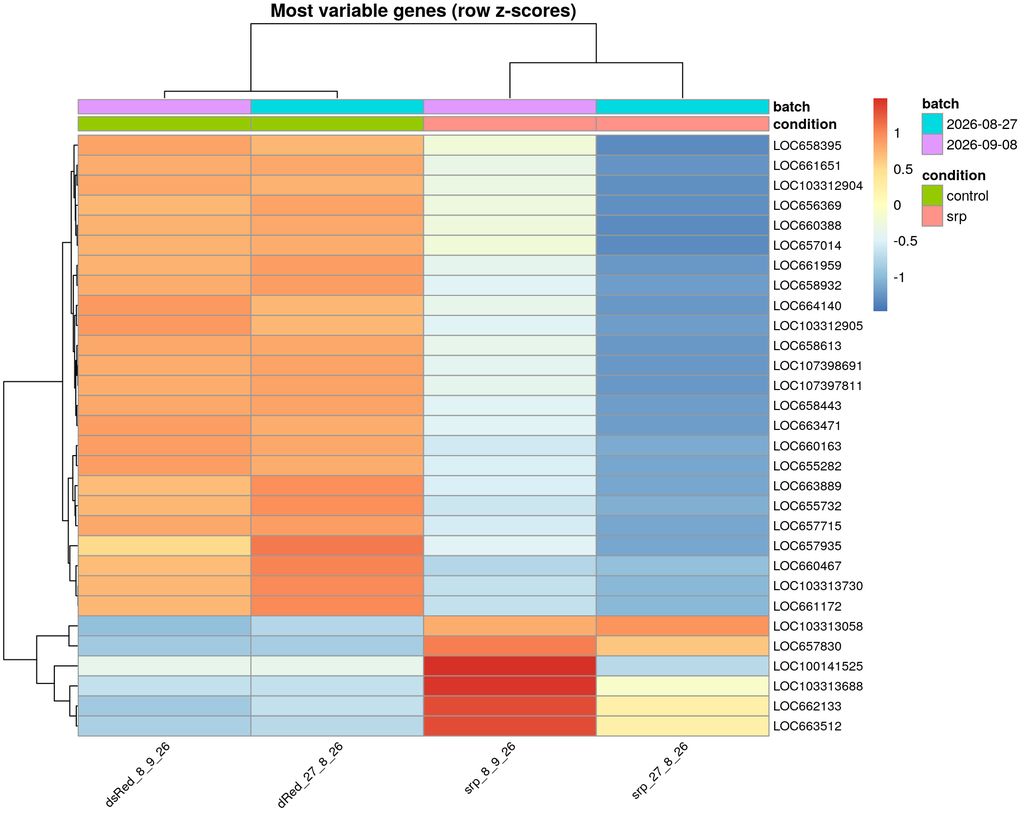

```r
v <- apply(assay(rld), 1, var)
top_var <- head(names(sort(v[v > 0], decreasing = TRUE)), 30)
if (length(top_var) >= 2) {
  heat_mat <- assay(rld)[top_var, , drop = FALSE]

  # Match gene names to matrix rows by gene ID.
  gene_labels <- as.character(ann$gene_name[
    match(rownames(heat_mat), as.character(ann$gene_id))
  ])
  gene_labels <- trimws(gene_labels)

  # Fall back to gene IDs when names are missing.
  missing_name <- is.na(gene_labels) |
    gene_labels %in% c("", "-", "NA")
  gene_labels[missing_name] <- rownames(heat_mat)[missing_name]

  # Distinguish genes that share a name.
  duplicate_name <- duplicated(gene_labels) |
    duplicated(gene_labels, fromLast = TRUE)
  gene_labels[duplicate_name] <- paste0(
    gene_labels[duplicate_name], " [",
    rownames(heat_mat)[duplicate_name], "]"
  )

  h <- pheatmap(
    heat_mat,
    scale = "row",
    annotation_col = annotation,
    labels_row = gene_labels,
    show_rownames = TRUE,
    fontsize_row = 9,
    fontsize_col = 9,
    angle_col = "45",
    main = "Most variable genes (row z-scores)",
    silent = TRUE
  )



# Save PDF.
  pdf(file.path(out, "variable_genes_heatmap.pdf"),
      width = 10, height = 8)
  grid::grid.newpage()
  grid::grid.draw(h$gtable)
  invisible(dev.off())

  # Save PNG for embedding in the knitted document.
  heatmap_png <- file.path(out, "variable_genes_heatmap.png")
  png(heatmap_png, width = 2000, height = 1600, res = 200)
  grid::grid.newpage()
  grid::grid.draw(h$gtable)
  invisible(dev.off())

  heatmap_display <- knitr::include_graphics(
    normalizePath(heatmap_png)
  )
} else {
  heatmap_display <- NULL
  cat("Too few variable genes to draw a heatmap.\n")
}

# This must be outside the if block, inside the R chunk.
heatmap_display
```

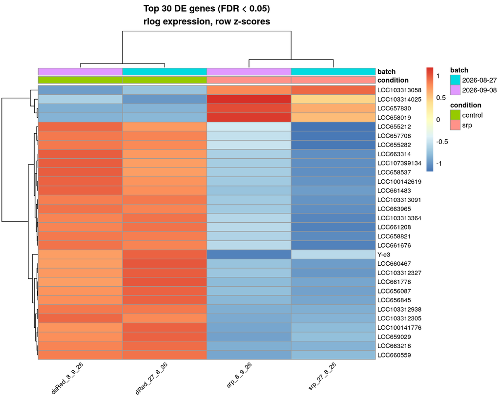

```r
top_degs <- res_tbl %>%
  dplyr::filter(!is.na(padj), padj < alpha) %>%
  dplyr::arrange(padj) %>%
  head(30)

deg_heatmap_display <- NULL

if (nrow(top_degs) > 0) {
  deg_mat <- assay(rld)[top_degs$gene_id, , drop = FALSE]

  # Gene-name labels in the same order as the matrix rows.
  gene_labels <- trimws(as.character(top_degs$gene_name))
  missing_name <- is.na(gene_labels) |
    gene_labels %in% c("", "-", "NA")
  gene_labels[missing_name] <- top_degs$gene_id[missing_name]

  duplicate_name <- duplicated(gene_labels) |
    duplicated(gene_labels, fromLast = TRUE)
  gene_labels[duplicate_name] <- paste0(
    gene_labels[duplicate_name], " [",
    top_degs$gene_id[duplicate_name], "]"
  )

  deg_annotation <- coldata[
    colnames(deg_mat), c("condition", "batch"), drop = FALSE
  ]

  deg_h <- pheatmap::pheatmap(
    deg_mat,
    scale = "row",
    cluster_rows = nrow(deg_mat) > 1,
    annotation_col = deg_annotation,
    labels_row = gene_labels,
    show_rownames = TRUE,
    fontsize_row = 9,
    fontsize_col = 9,
    angle_col = "45",
    main = paste0(
      "Top ", nrow(deg_mat), " DE genes (FDR < ", alpha, ")\n",
      "rlog expression, row z-scores"
    ),
    silent = TRUE
  )

  # Save PDF.
  pdf(file.path(out, "top30_DEGs_heatmap.pdf"),
      width = 10, height = 8)
  grid::grid.newpage()
  grid::grid.draw(deg_h$gtable)
  invisible(dev.off())

  # Save PNG for the knitted document.
  deg_png <- file.path(out, "top30_DEGs_heatmap.png")
  png(deg_png, width = 2000, height = 1600, res = 200)
  grid::grid.newpage()
  grid::grid.draw(deg_h$gtable)
  invisible(dev.off())

  deg_heatmap_display <- knitr::include_graphics(
    normalizePath(deg_png)
  )
} else {
  cat("No genes pass the adjusted P-value threshold; no DEG heatmap drawn.\n")
}

# Outside the if/else block so knitr renders the image.
deg_heatmap_display
```

## MA, volcano and uncertainty

Volcano labels show the ten lowest-FDR significant genes, or the ten lowest-FDR tested genes when none is significant. Dashed fold-change lines are descriptive; the P values test a zero condition effect, not the dashed thresholds.

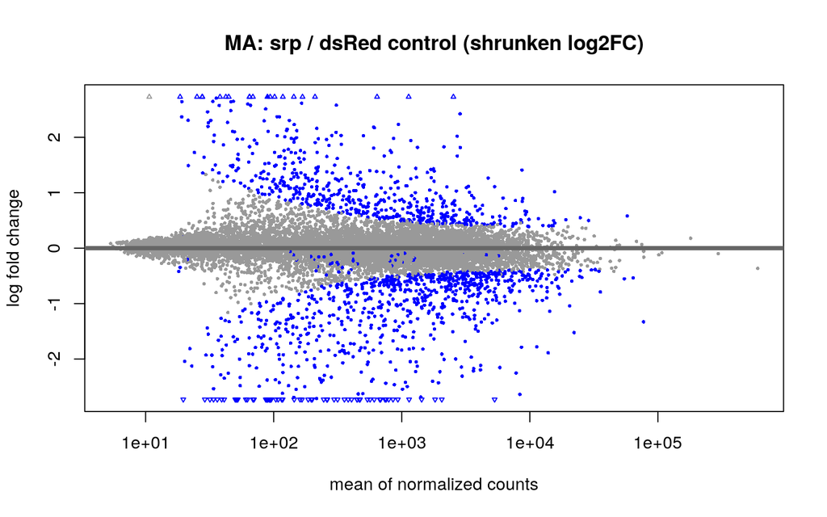

```r
plotMA(shr, alpha = alpha, main = "MA: srp / dsRed control (shrunken log2FC)")
```

```r
pdf(file.path(out, "MA.pdf"), width = 7, height = 5)
plotMA(shr, alpha = alpha)
dev.off()
```

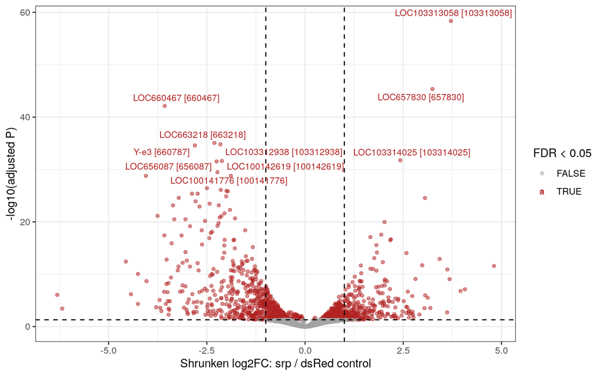

```r
tested <- res_tbl %>% dplyr::filter(!is.na(padj), is.finite(log2FC_shrunken)) %>%
  mutate(y = -log10(pmax(padj, .Machine$double.xmin)))
labels <- tested %>% dplyr::filter(DEG) %>% head(10)
if (nrow(labels) == 0) labels <- head(tested, 10)
save_plot(ggplot(tested, aes(log2FC_shrunken, y, color = DEG)) +
  geom_point(alpha = 0.5, size = 1.2) +
  geom_vline(xintercept = c(-lfc_cut, lfc_cut), linetype = 2) +
  geom_hline(yintercept = -log10(alpha), linetype = 2) +
  geom_text_repel(data = labels, aes(label = label), seed = 42, max.overlaps = Inf,
                  size = 3) + scale_color_manual(values = c("grey65", "firebrick")) +
  theme_bw() + labs(x = "Shrunken log2FC: srp / dsRed control", y = "-log10(adjusted P)",
                    color = "FDR < 0.05"), "volcano", 6)
```

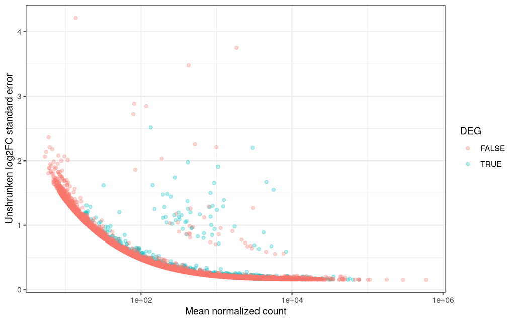

```r
save_plot(ggplot(res_tbl %>% dplyr::filter(baseMean > 0, is.finite(lfcSE)),
                 aes(baseMean, lfcSE, color = DEG)) + geom_point(alpha = 0.3) +
  scale_x_log10() + theme_bw() +
  labs(x = "Mean normalized count", y = "Unshrunken log2FC standard error"), "LFC_uncertainty")
```

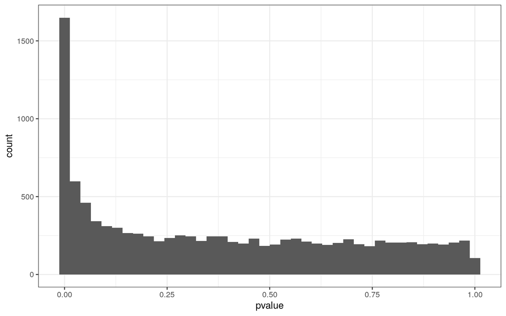

```r
save_plot(ggplot(res_tbl %>% dplyr::filter(!is.na(pvalue)), aes(pvalue)) +
  geom_histogram(bins = 40) + theme_bw(), "pvalue_histogram")
```

## Inspect individual samples

Top-gene points show normalized counts, not batch-adjusted expression. Compare the two dates and check whether a candidate effect is driven by one sample. Cook’s distances flag influential observations; with two samples per condition, default DESeq2 outlier filtering/replacement has important limitations. Do not automatically exclude samples or genes based on this plot.

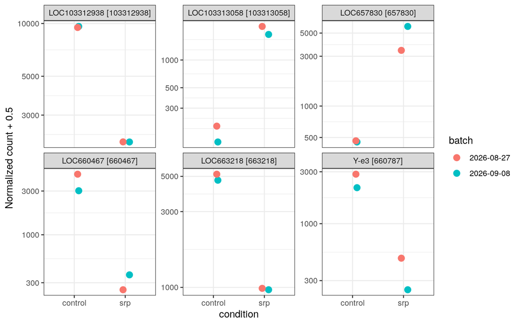

```r
if (nrow(labels) > 0) {
  top_counts <- as.data.frame(norm[head(labels$gene_id, 6), , drop = FALSE]) %>%
    rownames_to_column("gene_id") %>% pivot_longer(-gene_id, names_to = "sample",
                                                  values_to = "count") %>%
    left_join(meta, by = "sample") %>%
    left_join(res_tbl %>% dplyr::select(gene_id, label), by = "gene_id")
  save_plot(ggplot(top_counts, aes(condition, count + 0.5, color = batch)) +
    geom_point(position = position_jitter(width = 0.1, height = 0, seed = 42), size = 3) +
    scale_y_log10() + facet_wrap(~ label, scales = "free_y") + theme_bw() +
    labs(y = "Normalized count + 0.5"), "top_gene_counts", 7)
}
```

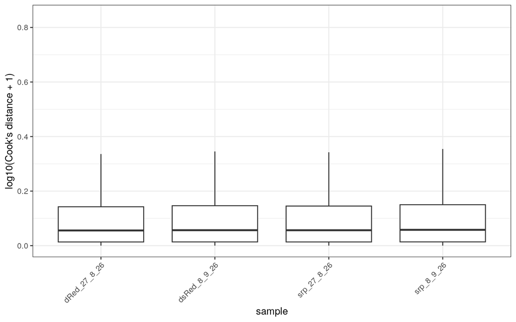

```r
cooks <- as.data.frame(assays(dds)[["cooks"]]) %>%
  pivot_longer(everything(), names_to = "sample", values_to = "cooks")
save_plot(ggplot(cooks %>% dplyr::filter(is.finite(cooks)),
                 aes(sample, log10(cooks + 1))) + geom_boxplot(outlier.shape = NA) +
  theme_bw() + theme(axis.text.x = element_text(angle = 45, hjust = 1)) +
  labs(y = "log10(Cook's distance + 1)"), "Cooks_distances")
```

```r
saveRDS(list(dds = dds, rlog = rld, results = res_tbl, metadata = meta),
        file.path(out, "DESeq2_analysis.rds"))
writeLines(capture.output(sessionInfo()), file.path(out, "sessionInfo.txt"))
```

## Deciding whether to add biological replicates

With **two independent biological samples per condition**, inference is preliminary. High dispersion, wide effect uncertainty, inconsistent top-gene counts, or strong batch structure support collecting more independent samples. An absence of significant genes does not establish an absence of a condition effect. Balance both conditions across new processing batches.

Additional sequencing of existing libraries improves sampling precision but does not add biological replication. If counts are already high while dispersion and uncertainty remain high, more biological samples may help more than greater depth. Count totals and detected genes alone cannot establish sequencing saturation. Examine Novogene/FastQC/MultiQC metrics (mapping, duplication, rRNA, library complexity and RNA quality) before deciding on resequencing.

These QC plots do not provide a reliable required sample size from four samples. Plan replication using a biologically meaningful effect size, target FDR/power, and conservative dispersion estimates from this pilot or a larger comparable dataset. Do not choose a model or exclude samples to increase the DEG count.

Reference: [DESeq2 vignette](https://bioconductor.org/packages/release/bioc/vignettes/DESeq2/inst/doc/DESeq2.html).